## **The Clock is Ticking: How Do Americans Spend Their Time?**

#### Authors: Jaeyeon Won (Project Coordinator), Becca Barrick, Jay Maxwell, Alec Meyer, and Tessa Mendoza

## **Introduction**

Every day, individuals in America differently allocate their time between various activities, such as work, leisure, personal care, socializing, and other activities. As understanding this individual time usage is a complicated task, exploring the their time usage as a whole can be helpful in obtaining the general picture on human activity. Practically, it could also be the most valuable resources for promoting social and economic activities performed in the United States, by providing informative analysis. With the purpose of gaining insight into how Americans spend their time, this project investigates the overall trends and patterns of their activity time use in relation to several interesting factors, using various visualizations. Specifically, we explore 7 different types of time use: ‘Eating & Drinking’, ‘Personal Care’, ‘Religious & Spiritual Activities’, ‘Socializing, Relaxing & Leisure’, ‘Sports, Exercise & Recreation’, ‘Traveling’, and ‘Work & Work-Related Activities.’

[figure not shown]

*People,* 3 January. 2019, *SecretNYC*

## **Research Questions**

To achieve our goal, we have developed five general areas of exploration with the following five research questions:

- What are the overall time usage patterns for different demographic?
- How did the trend of time usage change over the last 15 years?
- How are individual’s perceived life satisfaction and time usage related?
- How are individual’s general health status and time usage related?
- What factors are related to individual’s work and travel time?

## **Overview of the Dataset**

This section describes how we obtained and cleaned the dataset for this project.

#### **Obtaining the Dataset**

The dataset *time.cvs* comes from the *IPUMS Time Use*, a collaborative research data portal that provides demographic, socioeconomic, household, and daily time use data from survey respondents. Specifically, the dataset was extracted from the *American Time Use Survey (ATUS)* (https://timeuse.ipums.org/), which provides U.S. time diary survey data for period since 2003, using the ATUS extract builder.

The extracted dataset contains 39 variables for approximately 189,866 observations collected from 2004 to 2019. 7 of them are time use variables that were used as response variables, and the other 32 are additional variables that were used to investigate the associations to the time use variables.

#### **Cleaning the Datset**

The data cleaning process was made relatively simple by the ATUS extract builder, since we were able to export the dataset only with the necessary variables directly as a csv file. The categorical variables in the extracted dataset were encoded as numerical values. To clean this, we renamed the levels with appropriate names based on the codebook provided by the ATUS extract builder.

Our dataset and the codebook can be found at https://github.com/tessamendoza/ds202_project.git.

## **Exploratory Analysis**

This section explores the basic information about how demographic and living locations are associated to time usage. The demographic factors include age, gender, and race, and the geographical factors involve region and state. The analysis on associations between geography and time use does not include Alaska and Hawaii.

**- How Does Time Usage Differ By Age Group?**

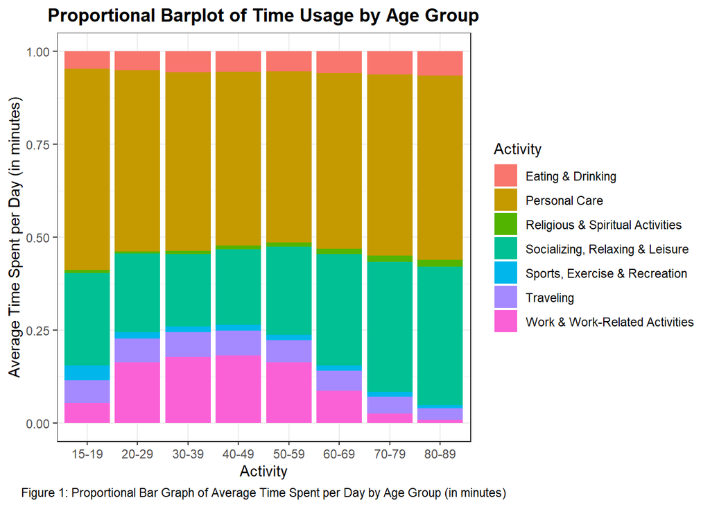

**- How Does Time Usage Differ By Gender?**

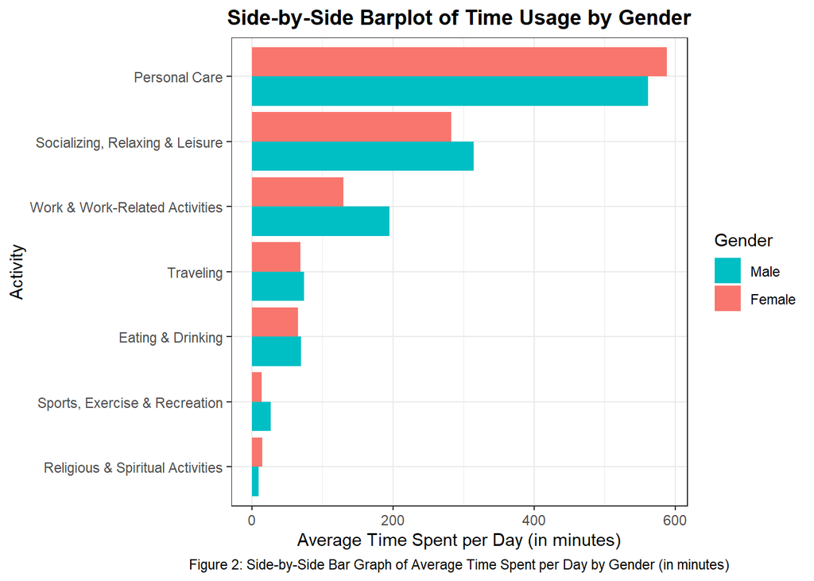

We see the time usage pattern by gender in Figure 2. Here, it is clear that both males and females spend the most time on personal care and the least time on religious activities. Looking closer, we can also see that males spend relatively more time on socializing, working, traveling, eating and drinking, and exercising than females. On the other hand, females spend more time on their personal care and religious activities than males do.

**- How Does Time Usage Differ By Race?**

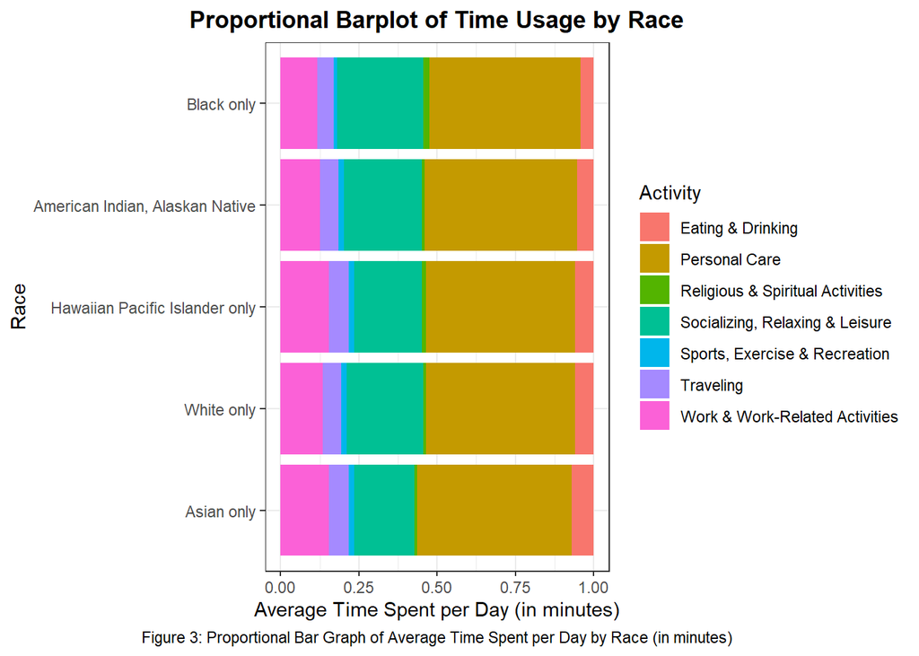

Analyzing the the relationship between race and time usage, we found the results above in Figure 3. In detail, we found that different races have a similar trend in general. However, Hawaiian Pacific islanders as well as Asians are determined to spend more time working, on average, than other races. Asians also tend to allocate more time for personal care and eating and drinking. Despite Asians’ tendency to work more, they spend the least time socializing, relaxing, and doing leisure activities than other races do.

**- How Does Time Usage Differ By U.S. Region?**

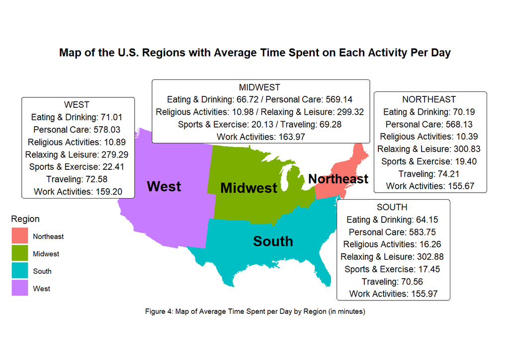

In terms of the geographical relations to American’s time use pattern, we firstly looked at the regions in the United States, which are divided into the four following areas: West, Midwest, Northeast, and South. Based on Figure 4, we observe that people in the West tend to eat and drink the most (71 minutes per day) while the people in the South spend the least time on this activity (64 minutes per day). Similarly, Western people spend around 22 minutes per day on sports, exercise, and recreation, as the leading active region, whereas the Southern people spend the least amount of time (17 minutes per day). On the contrary, these two regions show an opposite pattern in terms of the socializing, relaxing, and leisure activities. For example, Southern residents spend the most time (302 minutes per day) for these activities, whereas the Western people spend the least time (279 minutes per day). Regarding personal care and religious activities, both activities are the most popular in the South while they are both the least popular in the Northeast. The residents in the Midwest are the most hard-working people, while they spend the least time traveling. Unlike from the Midwestern people, the Northeast spends the least time on work-related activities and the most time traveling.

**- How Does Time Usage Differ By State?**

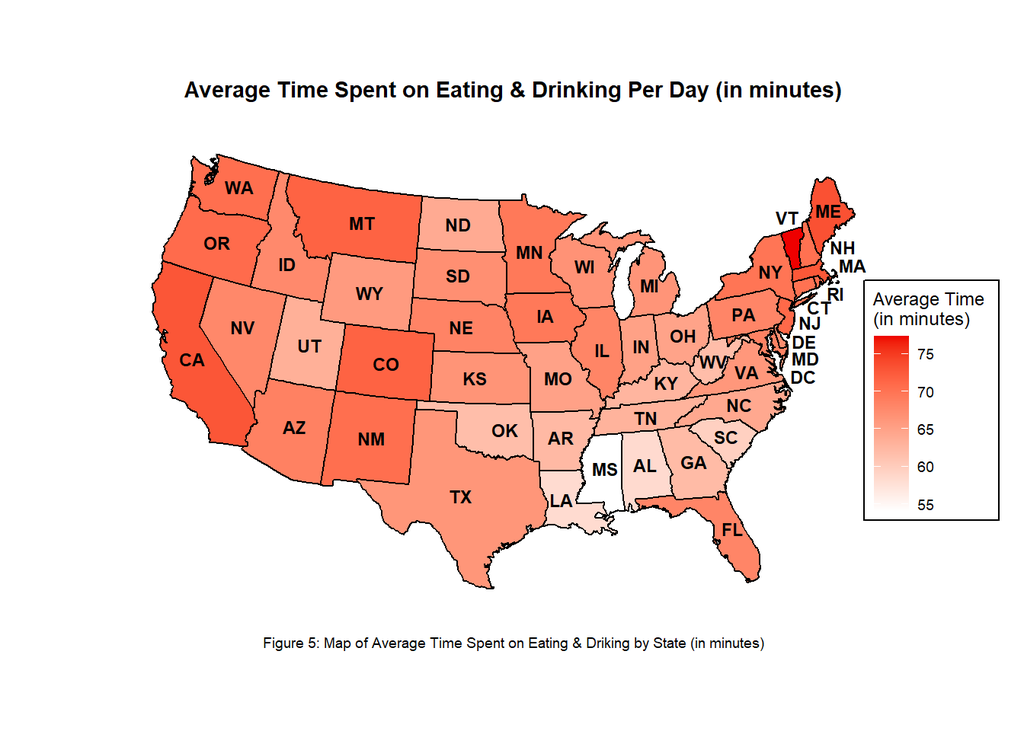

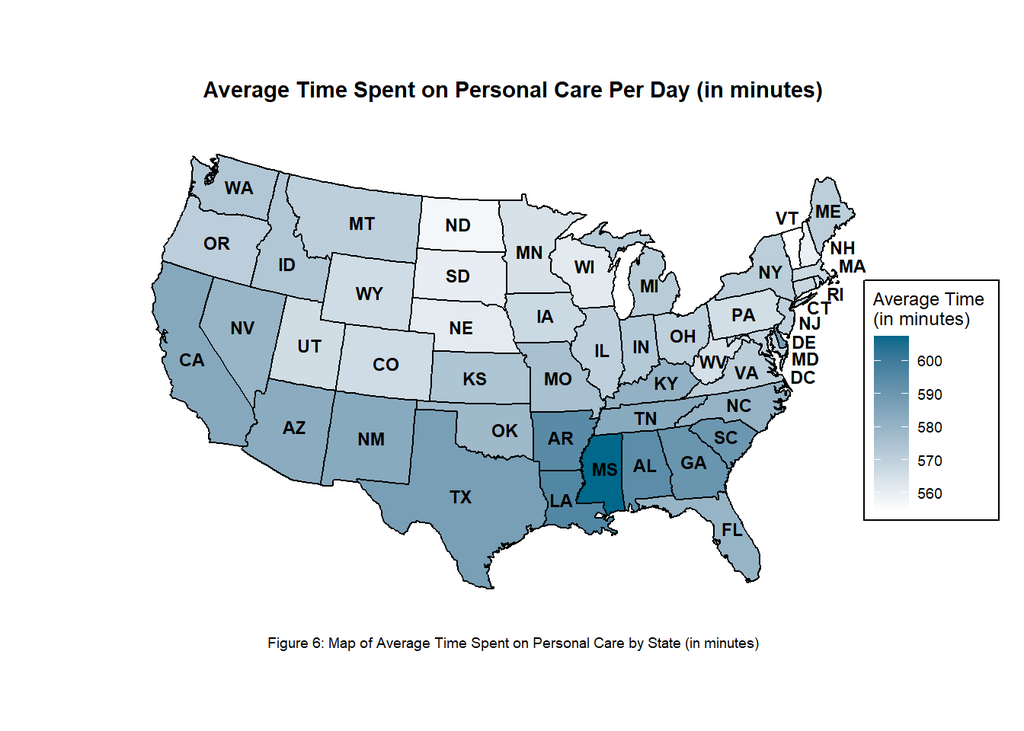

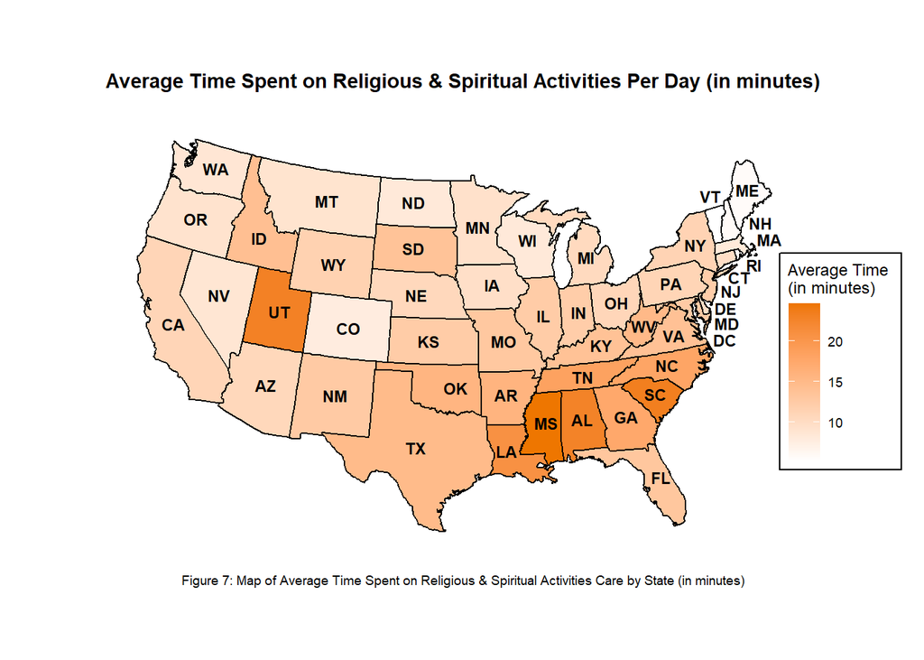

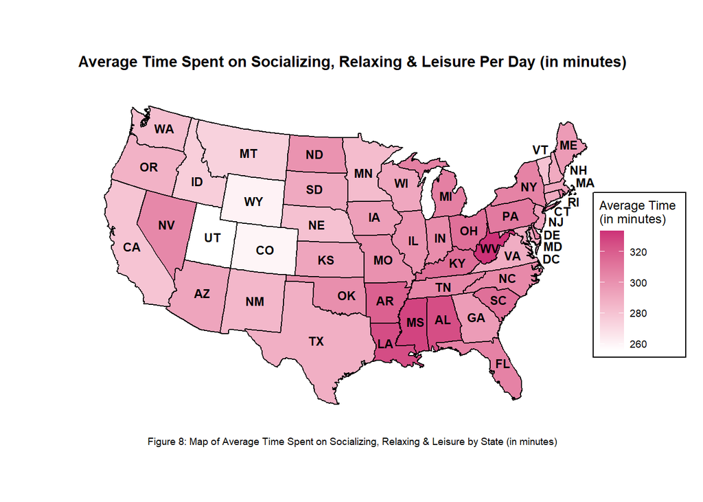

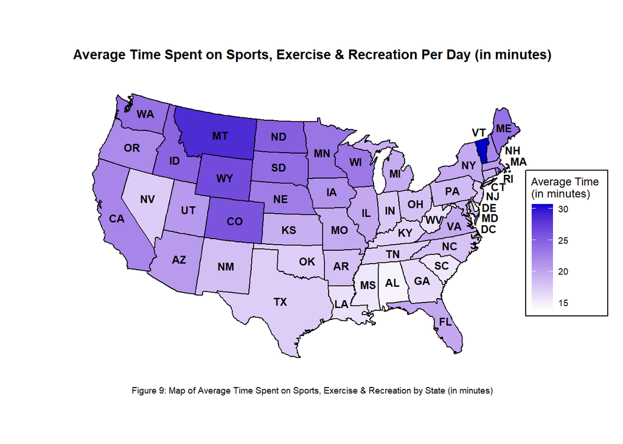

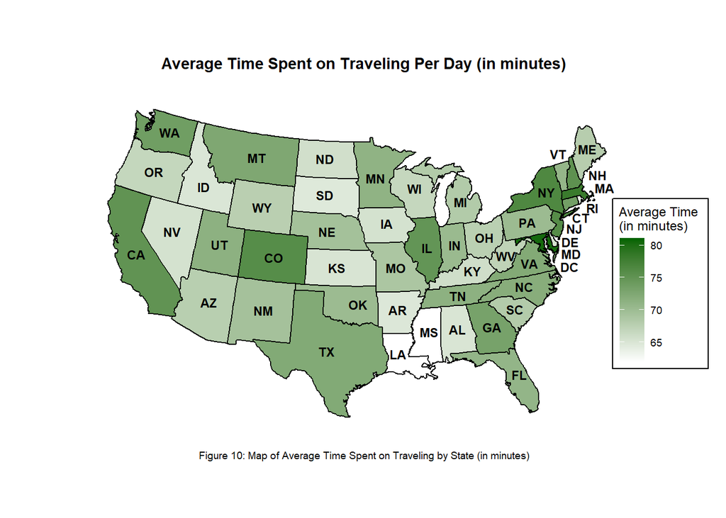

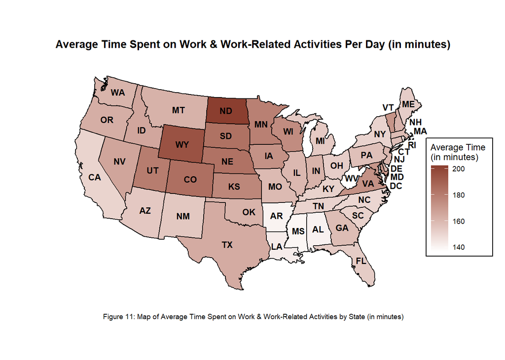

Different time use patterns by state for various types of activities are shown in the 7 maps above. The states with more time spent on each activity are colored in darker colors, and the states with less time spent are colored in brighter colors.

## **Time Usage Over Time**

This part of the paper investigates how the time usage pattern has changed over the last 15 years from 2004 to 2019. We specifically analyzed the time use trend of the religious and spiritual activities as well as the work and work-related activities.

**- Has time spent engaged in religious and spiritual activities changed over the last 15 years?**

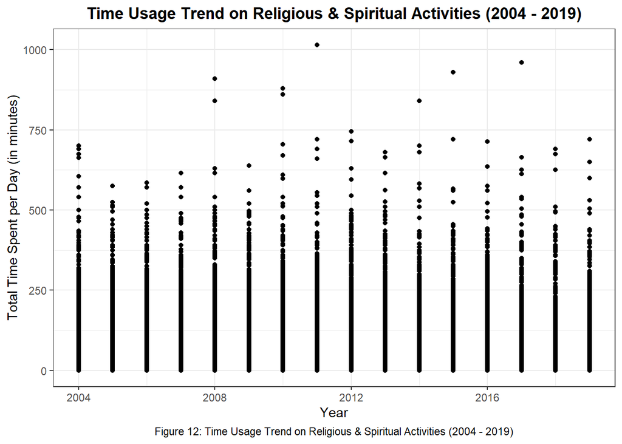

**- Are Americans working more or less than they used to?**

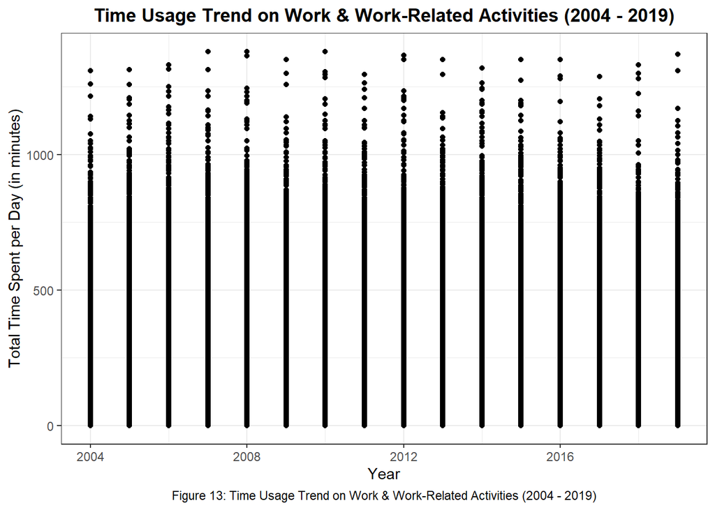

**- How has time spent working changed in various regions of the U.S.?**

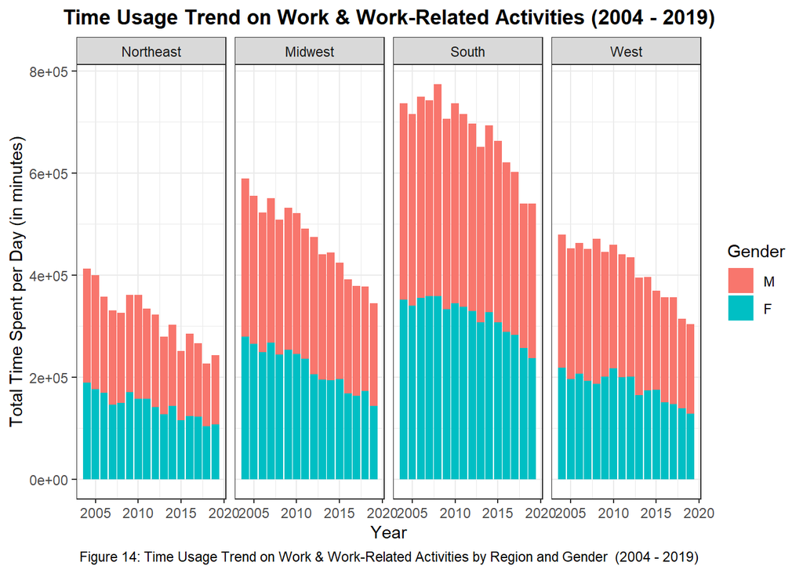

## **Life Satisfaction & Time Usage**

This part of analysis shows American’s life satisfaction with respect to their time allocation between different types of activities, especially focusing on the work and social activities.

**- How are each type of activities related to life satisfaction?**

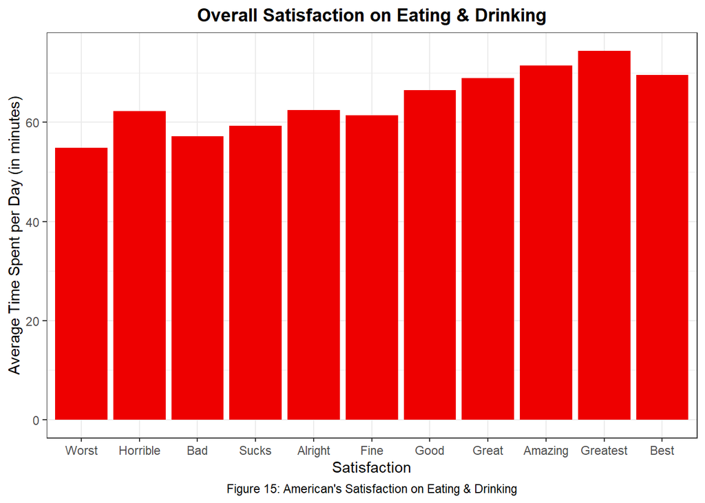

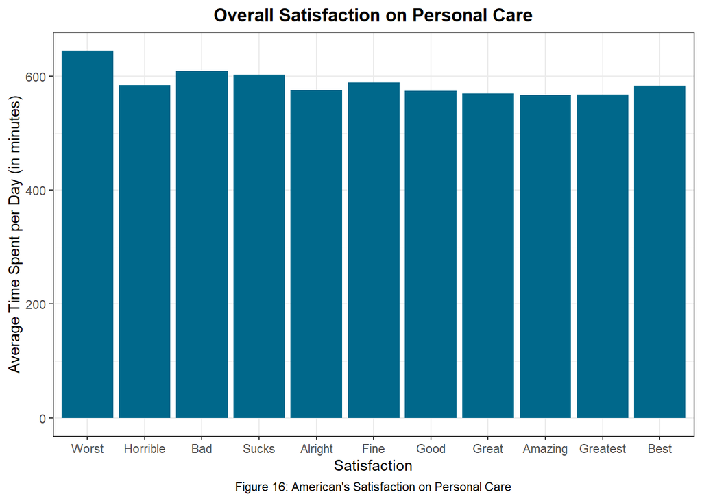

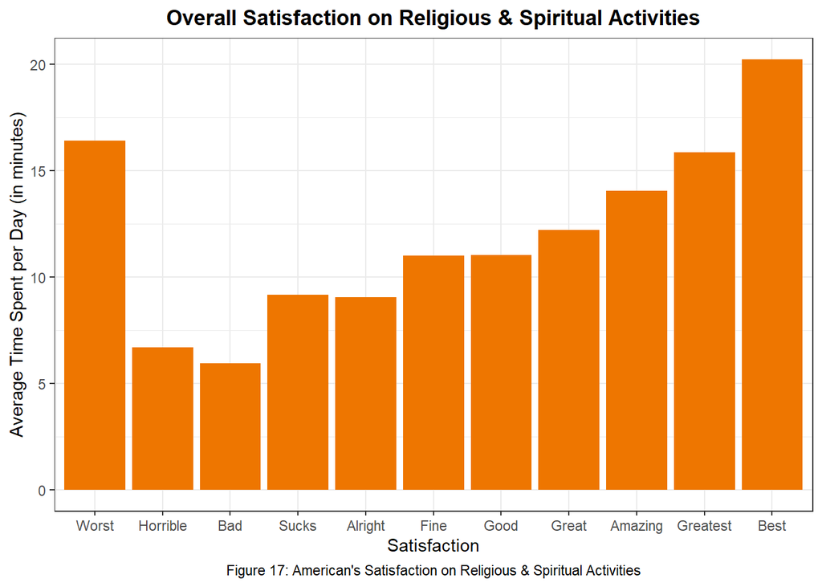

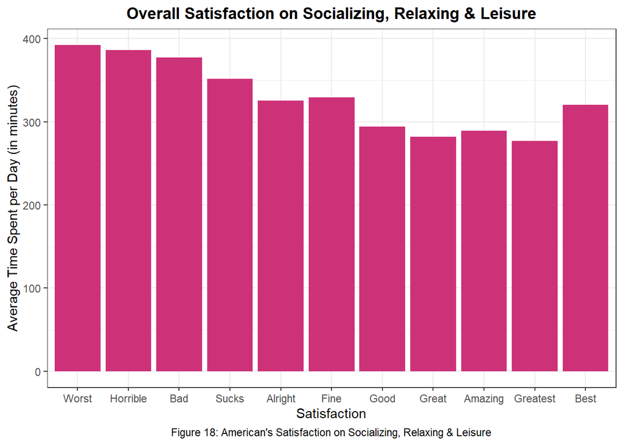

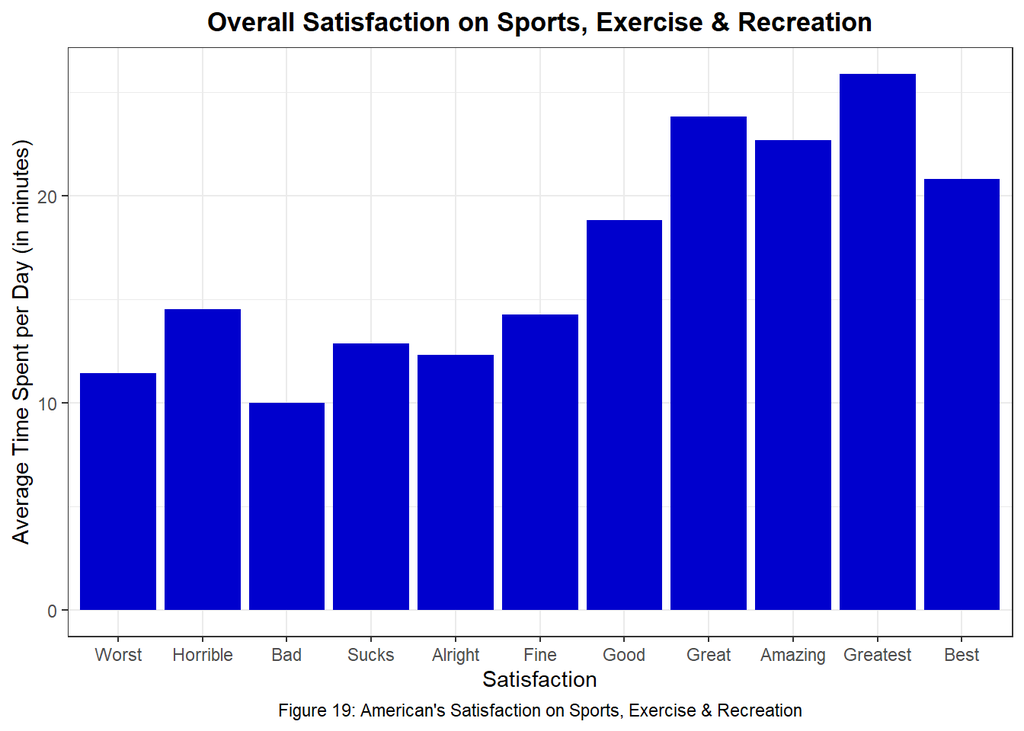

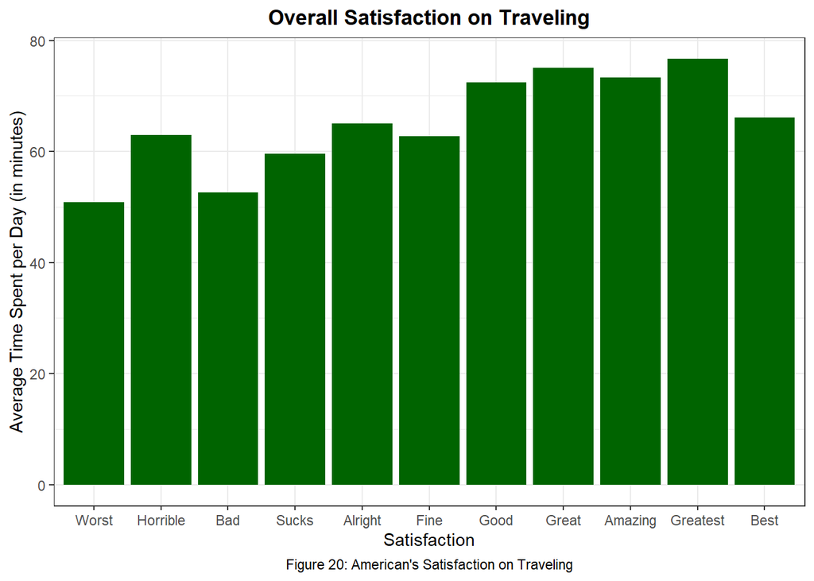

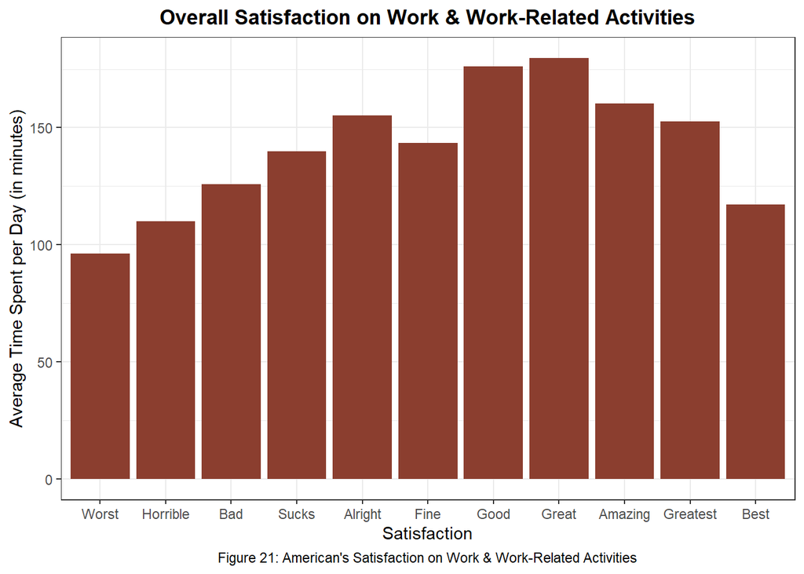

Each of these above graphs shows the average minutes of time at each life quality that people reported for the activity. The most interesting graph of these is the religious activities. There is a large drop off from the first bar where we would assume people are being forced to attend religious activities. Another interesting set would be the personal care graph. Personal care includes sleep which will take up most of the personal care time. Based on this it shows that the more you sleep the lower your life satisfaction.

**- Which region in the U.S. has the highest / lowest life satisfaction?**

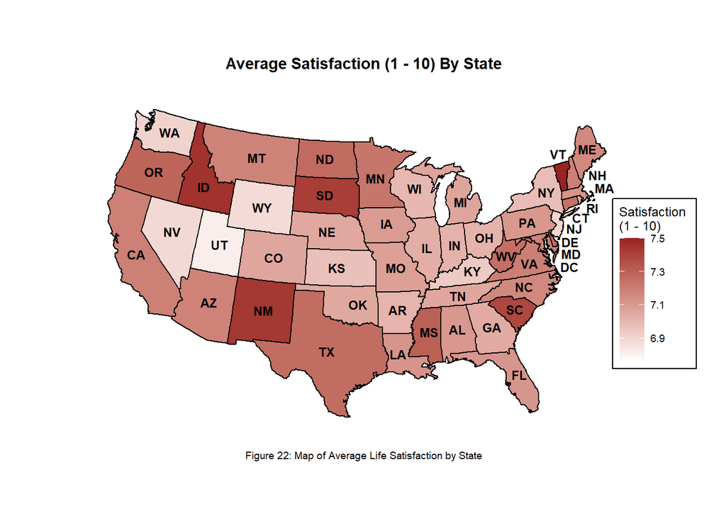

Based on Figure 22, most of the regions seem to show a fairly equal life satisfaction. However, Vermont, Idaho, New Mexico, and South Dakota are the most satisfied states with the average satisfaction rating of around 7.4 - 7.5. On the other hand, DC, Utah, Wyoming, Nevada, and New Jersey are the lesat satisfied states with the average life satisfaction rating of around 6.7 - 6.8.

**- Which region spends the most time working?**

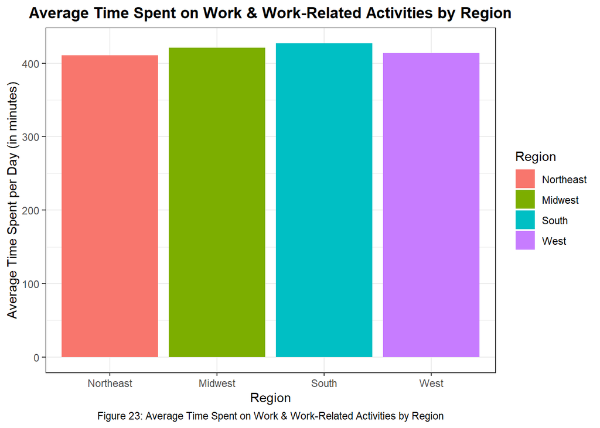

According to Figure 23, where it shows the time use trend by region, it is easy to see that all of the regions work for a similar amount of time per day. However, the South is determined to be the highest working region with whereas the Northeast and West are the lowest working regions.

**- Which region is the most social? Does this correspond with life satisfaction?**

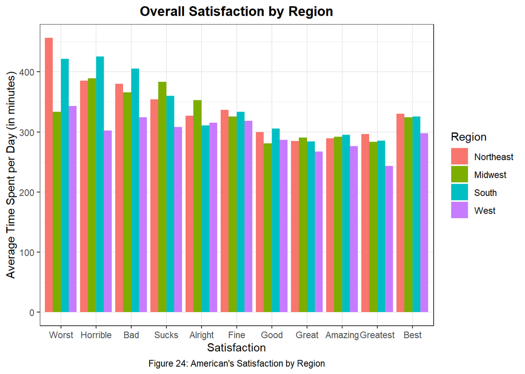

## **Health & Time Usage**

#### **Physical Activity**

The data provided in this dataset includes individuals ranging from 15-85 years of age. Specifically, this section of analysis explores the ‘Sports’ time use variable, which highlights the amount of time an individual spends on sports, exercise, and recreation in a day. This will be referenced as physical activity in the future.

**- Which age range spends the most time engaging in physical activity?**

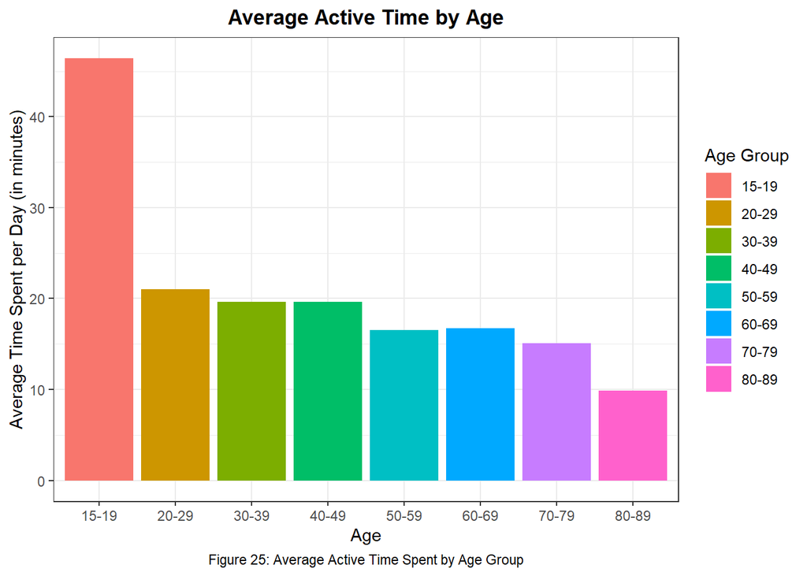

Based on Figure 25, the 15-19 year old group spends, on average, the greatest time doing sports, exercise and recreation - over double the amount of time compared to every other age group. Activity level tends to decline as age increases.

**- Does time spent engaging in physical activity vary by state?**

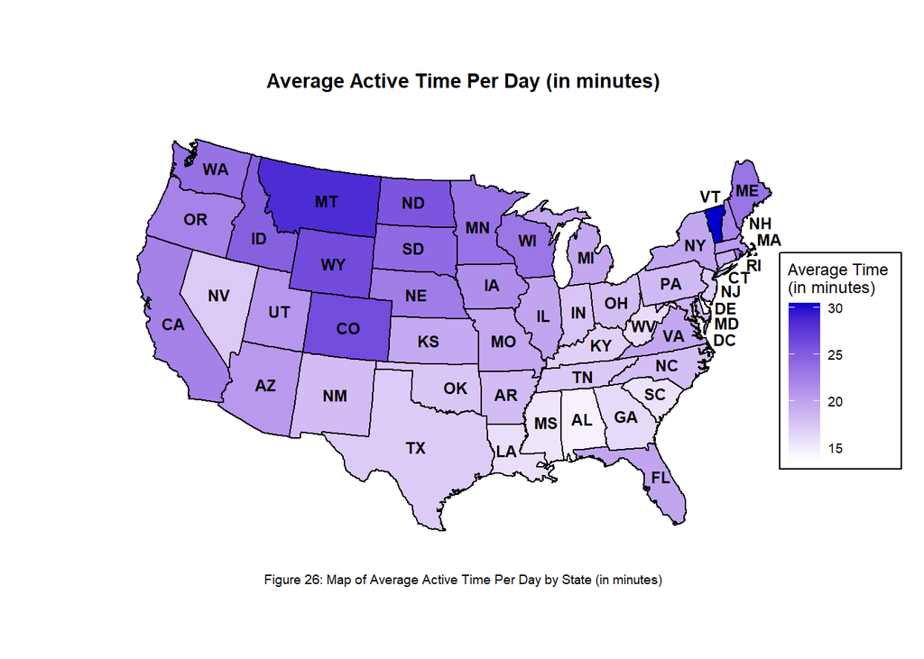

**- Do activity levels among youth (individuals under 20) vary by state?**

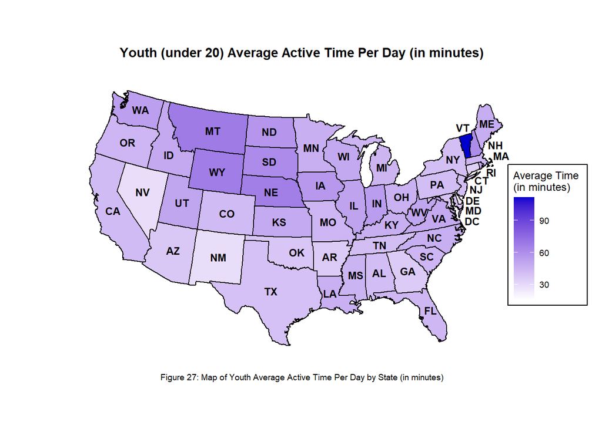

According to Figure 27, states in the Midwest and Northwest tend to have more active youth than states in the Southwest and Southeast regions. Vermont has the most active youth.

#### **BMI**

BMI, or Body Mass Index, is a measure of body fat based on height and weight that is commonly used in the healthcare setting. The BMI data was recorded in the ATUS survey series between 2006-2008 and 2014-2016. The BMI ranges (underweight, normal, overweight, and obese), are determined according to the Centers for Disease Control (CDC) standard. It is important to note that BMI is NOT the most accurate predictor of health status, however, it is a useful tool and provides a general marker for individual health, especially on a large-scale level. More information on BMI can be found on the CDC’s website (see works cited section for link).

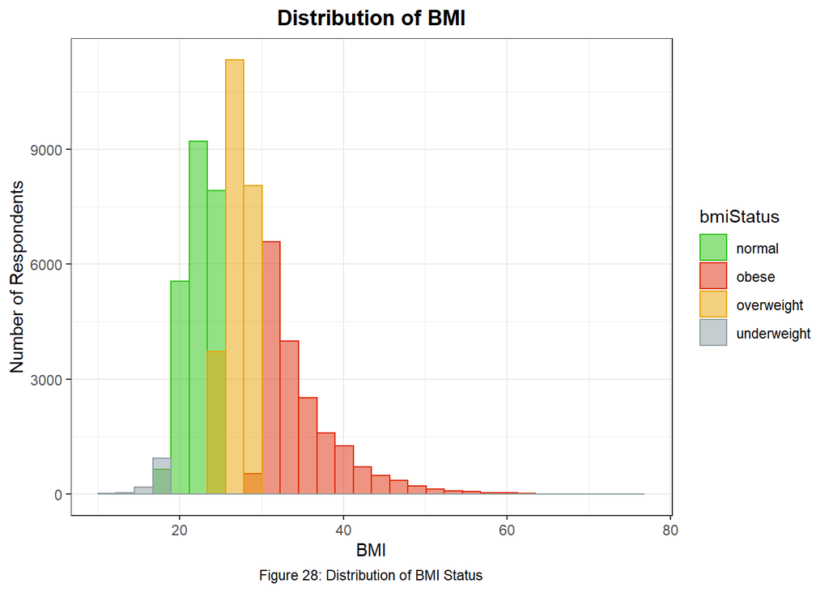

Figure 28 shows the distribution of BMI’s among individuals. BMI status was calculated using the CDC standard and was manually added to the dataset. The most frequent BMI values occur at the higher end of the normal range and at the lower end of the overweight category.

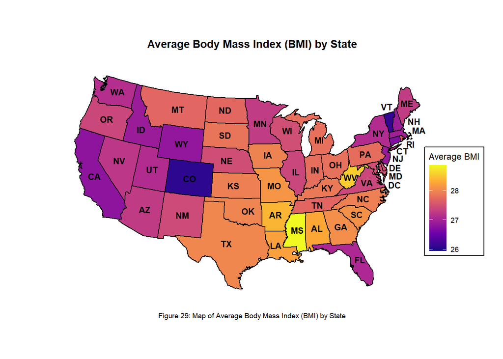

This BMI map was made, using ggplot, by combining average BMI data for each state with an imported ‘state’ map (mentioned above). Colorado and Vermont have the healthiest individuals according to BMI, with the West coast, Northeast, and Florida following closely behind. The Midwest has a higher BMI and South regions have higher BMI, as does West Virginia.